# Titanic: Machine Learning from Disaster

The sinking of the RMS Titanic is one of the most infamous shipwrecks in history. On April 15, 1912, during her maiden voyage, the Titanic sank after colliding with an iceberg, killing 1502 out of 2224 passengers and crew. This sensational tragedy shocked the international community and led to better safety regulations for ships.

One of the reasons that the shipwreck led to such loss of life was that there were not enough lifeboats for the passengers and crew. Although there was some element of luck involved in surviving the sinking, some groups of people were more likely to survive than others, such as women, children, and the upper-class.

## Goal

```python
# importing libraries
import os
import io
import warnings

import numpy as np
import scipy as sp
import pandas as pd
import sklearn as sk

import matplotlib as mpl
import matplotlib.pyplot as plt
%matplotlib inline
import seaborn as sns
sns.set()

warnings.simplefilter(action='ignore', category=FutureWarning)
```

```python
# load data
titanic = pd.read_csv('https://raw.githubusercontent.com/zariable/UW-MSIS522/master/assignment/data/titanic_train.csv')
display(titanic.head())
```

|  | PassengerId | Survived | Pclass | Name | Sex | Age | SibSp | Parch | Ticket | Fare | Cabin | Embarked |
| --- | --- | --- | --- | --- | --- | --- | --- | --- | --- | --- | --- | --- |
| 0 | 1 | 0 | 3 | Braund, Mr. Owen Harris | male | 22.0 | 1 | 0 | A/5 21171 | 7.2500 | NaN | S |
| 1 | 2 | 1 | 1 | Cumings, Mrs. John Bradley (Florence Briggs Th... | female | 38.0 | 1 | 0 | PC 17599 | 71.2833 | C85 | C |
| 2 | 3 | 1 | 3 | Heikkinen, Miss. Laina | female | 26.0 | 0 | 0 | STON/O2. 3101282 | 7.9250 | NaN | S |
| 3 | 4 | 1 | 1 | Futrelle, Mrs. Jacques Heath (Lily May Peel) | female | 35.0 | 1 | 0 | 113803 | 53.1000 | C123 | S |
| 4 | 5 | 0 | 3 | Allen, Mr. William Henry | male | 35.0 | 0 | 0 | 373450 | 8.0500 | NaN | S |

## Description of the data set

Here's a brief description of each column in the data.

- PassengerID: A column added by Kaggle to identify each row and make submissions easier
- Survived: Whether the passenger survived or not and the value we are predicting (0=No, 1=Yes)
- Pclass: The class of the ticket the passenger purchased (1=1st, 2=2nd, 3=3rd)
- Sex: The passenger's sex
- Age: The passenger's age in years
- SibSp: The number of siblings or spouses the passenger had aboard the Titanic
- Parch: The number of parents or children the passenger had aboard the Titanic
- Ticket: The passenger's ticket number
- Fare: The fare the passenger paid
- Cabin: The passenger's cabin number
- Embarked: The port where the passenger embarked (C=Cherbourg, Q=Queenstown, S=Southampton)

```python
titanic.describe(include='all')
```

|  | PassengerId | Survived | Pclass | Name | Sex | Age | SibSp | Parch | Ticket | Fare | Cabin | Embarked |
| --- | --- | --- | --- | --- | --- | --- | --- | --- | --- | --- | --- | --- |
| count | 891.000000 | 891.000000 | 891.000000 | 891 | 891 | 714.000000 | 891.000000 | 891.000000 | 891 | 891.000000 | 204 | 889 |
| unique | NaN | NaN | NaN | 891 | 2 | NaN | NaN | NaN | 681 | NaN | 147 | 3 |
| top | NaN | NaN | NaN | Hegarty, Miss. Hanora "Nora" | male | NaN | NaN | NaN | 1601 | NaN | G6 | S |
| freq | NaN | NaN | NaN | 1 | 577 | NaN | NaN | NaN | 7 | NaN | 4 | 644 |
| mean | 446.000000 | 0.383838 | 2.308642 | NaN | NaN | 29.699118 | 0.523008 | 0.381594 | NaN | 32.204208 | NaN | NaN |
| std | 257.353842 | 0.486592 | 0.836071 | NaN | NaN | 14.526497 | 1.102743 | 0.806057 | NaN | 49.693429 | NaN | NaN |
| min | 1.000000 | 0.000000 | 1.000000 | NaN | NaN | 0.420000 | 0.000000 | 0.000000 | NaN | 0.000000 | NaN | NaN |
| 25% | 223.500000 | 0.000000 | 2.000000 | NaN | NaN | 20.125000 | 0.000000 | 0.000000 | NaN | 7.910400 | NaN | NaN |
| 50% | 446.000000 | 0.000000 | 3.000000 | NaN | NaN | 28.000000 | 0.000000 | 0.000000 | NaN | 14.454200 | NaN | NaN |
| 75% | 668.500000 | 1.000000 | 3.000000 | NaN | NaN | 38.000000 | 1.000000 | 0.000000 | NaN | 31.000000 | NaN | NaN |
| max | 891.000000 | 1.000000 | 3.000000 | NaN | NaN | 80.000000 | 8.000000 | 6.000000 | NaN | 512.329200 | NaN | NaN |

### **Question 1: Find the number of missing values for each column.**

The first step in data analysis is to identify columns with missing data. Can you find the columns in this data with missing value as well as the number of records with missing value for each column?

```python
# TODO
#missing = titanic.isna()

print("\nMissing values :  ", titanic.isna().sum().values.sum())
print(titanic.isna().any())
print(titanic.isna().sum())
```

```
Missing values :   866
PassengerId    False
Survived       False
Pclass         False
Name           False
Sex            False
Age             True
SibSp          False
Parch          False
Ticket         False
Fare           False
Cabin           True
Embarked        True
dtype: bool
PassengerId      0
Survived         0
Pclass           0
Name             0
Sex              0
Age            177
SibSp            0
Parch            0
Ticket           0
Fare             0
Cabin          687
Embarked         2
dtype: int64
```

### **Question 2: Impute missing values.**

Now we've identified the following columns with missing values: *Age*, *Cabin* and *Embarked*. As the next step, we want to impute those missing values. There are three ways to impute the missing values:

- A constant value that has meaning within the domain.
- The mean, median or mode value based on non-missing values of that column.
- A random value drawn from other non-missing values of that column.

Please write code to impute the missing values as follows:

- the missing values of column *age* with the mean of that column.
- the missing values of column *Cabin* with a constant value 'other'.
- the missing values of column *Embarked* with the [mode](https://pandas.pydata.org/pandas-docs/stable/generated/pandas.DataFrame.mode.html) of that column.

```python
#TODO
mean = titanic['Age'].mean()
mode = titanic['Embarked'].mode()
#mode is "S"

titanic['Age'] = titanic['Age'].fillna(mean)
titanic['Cabin'] = titanic['Cabin'].fillna("other")
titanic['Embarked'] = titanic['Embarked'].fillna("S")

#OR
#titanic['Age'] = titanic['Age'].replace(" ", mean).astype('float')
#titanic['Cabin'] = titanic['Cabin'].replace(titanic.Cabin.isna(),  "other")
#titanic['Embarked'] = titanic['Embarked'].replace(" ", titanic['Embarked'].mode())
```

### **Question 3: What's the name of the person who has the 10th most expensive ticket?**

```python
# TODO
display(titanic.nlargest(10, 'Fare').iloc[[-1]])

#Name of person is: Baxter, Mr. Quigg Edmond (10th row)
```

|  | PassengerId | Survived | Pclass | Name | Sex | Age | SibSp | Parch | Ticket | Fare | Cabin | Embarked |
| --- | --- | --- | --- | --- | --- | --- | --- | --- | --- | --- | --- | --- |
| 118 | 119 | 0 | 1 | Baxter, Mr. Quigg Edmond | male | 24.0 | 0 | 1 | PC 17558 | 247.5208 | B58 B60 | C |

### **Question 4: Out of all the people who survived, what's the name of the person who has the 10th most expensive ticket?**

```python
# TODO
titanic_survived = titanic.loc[(titanic['Survived'] == 1),:]
display(titanic_survived.sort_values('Fare', ascending=False).head(10).iloc[[-1]])

# The name of the person is Endres, Miss. Caroline Louise.
```

|  | PassengerId | Survived | Pclass | Name | Sex | Age | SibSp | Parch | Ticket | Fare | Cabin | Embarked |
| --- | --- | --- | --- | --- | --- | --- | --- | --- | --- | --- | --- | --- |
| 716 | 717 | 1 | 1 | Endres, Miss. Caroline Louise | female | 38.0 | 0 | 0 | PC 17757 | 227.525 | C45 | C |

### **Question 5: Examine the survival rate**

Calculate the survival rate for different gender and Pclass combination and use a couple of sentences to describe your findings. Hint: pivot_table

```python
# TODO

#Only Gender Surival Rates
print(titanic.groupby('Sex').aggregate({
    'Survived': ['mean']
}))

#Only PClass Survival rates
print (titanic.groupby('Pclass').aggregate({
    'Survived': ['mean']
}))

#Combined pivot table
titanic.groupby(['Sex', 'Pclass']).aggregate({
    'Survived': ['mean']
})
```

```
        Survived
            mean
Sex
female  0.742038
male    0.188908
        Survived
            mean
Pclass
1       0.629630
2       0.472826
3       0.242363
```

| Sex | Pclass | Survived mean |
| --- | --- | --- |
| female | 1 | 0.968085 |
|  | 2 | 0.921053 |
|  | 3 | 0.500000 |
| male | 1 | 0.368852 |
|  | 2 | 0.157407 |
|  | 3 | 0.135447 |

From the tables, we can see that the survival rate for females are higher compared to males.

We also see that survival rates are highest for P-Class 1 (first class, 62.9%), as compared to 2nd class (47.3%) and 3rd class (24.2%). Thus, I assume that priority in emergency boarding was given to women, starting with higher P-classes.

### **Question 6: Is Age or Fare an important factor to one's chance of survival?**

Visualize the distribution of Column *Age* for both survived and non-survived population and write down your findings based on the visualization.

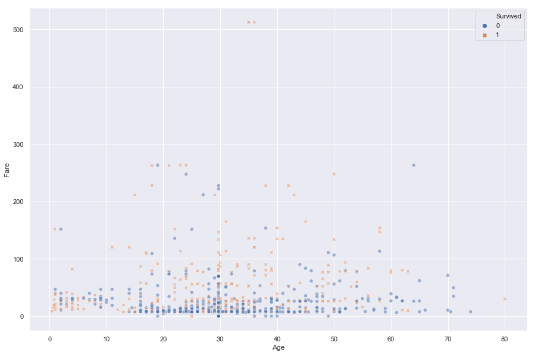

```python
# TODO
fig = plt.gcf()
fig.set_size_inches(15, 10)
ax = sns.scatterplot(x='Age', y='Fare', hue='Survived', style='Survived', alpha=0.5, data=titanic)
```

Findings are that age for survival seems to be rather mixed/distributed. There is a small cluser from 0-5 years on the bottom left corner (likely kids/babies) given priority in the emergency evaculation process. For adults, age is much more spread out from 20s-50s.

For the passengers that did not survive, it seems that the majority were young adults (heaviest concentration of blue around 20-30 years old). Perhaps these passengers deemed 'fit' were given last priority in emergency escape.

For fare, we can see that on average, people that paid higher fares had a better change of survival (higher class). This is compared to the blue dots (did not survive), which on average paid lower fares.

### **Question 7: Calculate and visualize the survival rate for discrete columns**

- Calculate the survival rate for column *SibSp* and *Parch*.
- Use sns.barplot to visualize the survival rate for column *SibSp* and *Parch*.

```
       Survived
           mean
SibSp
0      0.345395
1      0.535885
2      0.464286
3      0.250000
4      0.166667
5      0.000000
8      0.000000
       Survived
           mean
Parch
0      0.343658
1      0.550847
2      0.500000
3      0.600000
4      0.000000
5      0.200000
6      0.000000
```

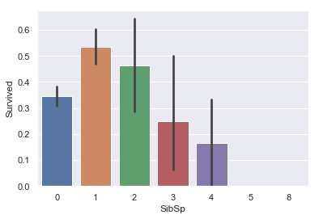

```python
# TODO
#Calculation
print(titanic.groupby('SibSp').aggregate({
    'Survived': ['mean']
}))

print(titanic.groupby('Parch').aggregate({
    'Survived': ['mean']
}))


#Visualization
sns.barplot("SibSp", "Survived", data=titanic)
```

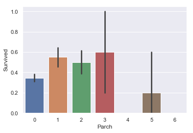

```python
sns.barplot("Parch", "Survived", data=titanic)
```

### **Question 8: Find the correlations.**

Find the correlations between the feature and the target variable *Survived* and use heatmap to visualize it. Summarize your findings.

```python
#First refreshing memory of all the feature names
print("\nFeatures : \n", list(titanic.columns))
```

```
Features :
 ['PassengerId', 'Survived', 'Pclass', 'Name', 'Sex', 'Age', 'SibSp', 'Parch', 'Ticket', 'Fare', 'Cabin', 'Embarked']
```

|  | PassengerId | Survived | Pclass | Name | Sex | Age | SibSp | Parch | Ticket | Fare | Cabin | Embarked |
| --- | --- | --- | --- | --- | --- | --- | --- | --- | --- | --- | --- | --- |
| PassengerId | 1.000000 | -0.005007 | 0.018305 | 1.000000 | -0.042939 | 0.123648 | -0.031023 | 0.001206 | 0.760875 | 0.299982 | 0.241918 | -0.030467 |
| Survived | -0.005007 | 1.000000 | 0.247845 | -0.005007 | 0.543351 | 0.037025 | -0.136302 | 0.086210 | -0.047298 | 0.191981 | 0.270495 | 0.106811 |
| Pclass | 0.018305 | 0.247845 | 1.000000 | 0.018305 | 0.118133 | 0.171190 | -0.149630 | -0.000343 | 0.020431 | 0.079498 | 0.187437 | -0.168091 |
| Name | 1.000000 | -0.005007 | 0.018305 | 1.000000 | -0.042939 | 0.123648 | -0.031023 | 0.001206 | 0.760875 | 0.299982 | 0.241918 | -0.030467 |
| Sex | -0.042939 | 0.543351 | 0.118133 | -0.042939 | 1.000000 | 0.005005 | -0.046152 | 0.242417 | -0.132709 | 0.137725 | 0.082104 | 0.116569 |
| Age | 0.123648 | 0.037025 | 0.171190 | 0.123648 | 0.005005 | 1.000000 | 0.010067 | 0.132659 | 0.074814 | 0.117313 | 0.163002 | -0.133308 |
| SibSp | -0.031023 | -0.136302 | -0.149630 | -0.031023 | -0.046152 | 0.010067 | 1.000000 | 0.165255 | -0.122426 | -0.046556 | -0.108709 | -0.030683 |
| Parch | 0.001206 | 0.086210 | -0.000343 | 0.001206 | 0.242417 | 0.132659 | 0.165255 | 1.000000 | -0.262607 | 0.074306 | -0.002761 | -0.085059 |
| Ticket | 0.760875 | -0.047298 | 0.020431 | 0.760875 | -0.132709 | 0.074814 | -0.122426 | -0.262607 | 1.000000 | 0.303257 | 0.212438 | -0.024655 |
| Fare | 0.299982 | 0.191981 | 0.079498 | 0.299982 | 0.137725 | 0.117313 | -0.046556 | 0.074306 | 0.303257 | 1.000000 | 0.379659 | 0.076726 |
| Cabin | 0.241918 | 0.270495 | 0.187437 | 0.241918 | 0.082104 | 0.163002 | -0.108709 | -0.002761 | 0.212438 | 0.379659 | 1.000000 | 0.017685 |
| Embarked | -0.030467 | 0.106811 | -0.168091 | -0.030467 | 0.116569 | -0.133308 | -0.030683 | -0.085059 | -0.024655 | 0.076726 | 0.017685 | 1.000000 |

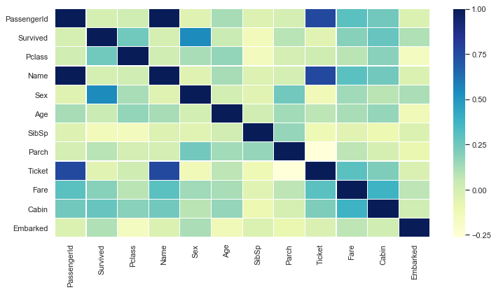

```python
# TODO
plt.figure(figsize=(12, 6))
corr = titanic[['PassengerId', 'Survived', 'Pclass', 'Name',
       'Sex', 'Age', 'SibSp', 'Parch',
       'Ticket', 'Fare', 'Cabin', 'Embarked']].apply(lambda x: pd.factorize(x)[0]).corr()
display(corr)
ax = sns.heatmap(corr, xticklabels=corr.columns, yticklabels=corr.columns, linewidths=.2, cmap="YlGnBu")
```

A darker color (closer to deep blue) indicates a higher correlation relationship (getting closer to 1).

Of course, the diagonal line represents corr = 1, because it is the variable against itself.

We are able to see an extremely high correlation between Name & PassengerID (which makes sense), and decreasing (but strong) levels of correlation for Name/Ticket, PassengerID/Ticket. The weakest correlation (or lackof) is between Parch - number of parents or children the passenger had aboard - and ticket

Other more useful correations we have already explored in previous questions include Sex/Survived, PClass/Survived, etc. So using this heapmap, we can quickly see which variables have the strongest correlations...very useful for specific variables of interest (like survival).

### **Question 9: Any other insights do you draw by analyzing the data? Summarize the findings as well as provide the code leading you to the findings.**

For my exploration, I am using Seaborn Pairplot to compare all the features, with color coding arranged by PClass (1st, 2nd and 3rd class) of the passenger. Resulting plots include histograms and scatter plots. The histogram on the diagonal allows us to see the distribution of single features (or variables), whereas the scatterplots demonstrate the relationships between two variables.

These pairs plot can generate valuable insights, such as being able to see that there seems to be negative correlation between SibSp (the number of siblings or spouses the passenger had aboard the Titanic) and Age. This is also found in SibSp against Faire (basically as faire increases, the number of sibilings/spouses in attandance decreases).

Although this information might not be as relevant for the purposes of post-disaster analysis, it is still useful in a business context. For example, if a ship maker was looking at bookings to learn about demographics/booking trends, a lack of siblings for older passengers might be opportunity to create a promotion (i.e. ticket price reduced) to try and increase this type of booking (seeing if lowing the faire helps increase tickets sold, etc.).

However, there is also a slightly positive correlation between Parch (number of parents or children the passenger had aboard and age. This means although siblings travel less freqently together (getting older), older adults may travel with more of their kids (younger generation) as a type of family vacation. Business insight can again be extracted on this.

In the next code block, I will re-plot SibSp and Age (same findings as above), just making it easier to see, and also with a regression line applied to the plot to better visualize the relationship's shape/strength clearly.

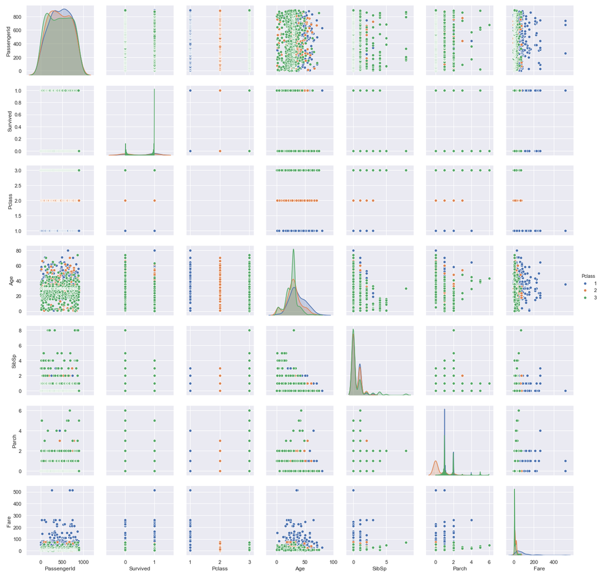

```python
# TODO
sns.pairplot(titanic, hue='Pclass')
#sns.pairplot(titanic, hue='Survived')
```

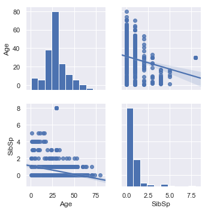

```python
sns.pairplot(titanic, vars=["Age", "SibSp"], kind="reg")
```

### **Bonus: Build a ML model to predict survival.**

Can you build a logistic regression model to predict the probability of survival for all the passengers in this [file](https://raw.githubusercontent.com/zariable/UW-MSIS522/master/assignment/data/titanic_test.csv)? How is your model accuracy?

Yes, we can build a logistic regression model to predict survival. However, the new file (test dataset) does not have 'Survived' column information, which means the evaluation of accuracy (on test set) cannot be determined. The other method would be splitting the training dataset (with survival) into seperate train/test sets (which would allow for all accuracy calculations to be performed). So I think this is actually a problem that's testing our understanding of the overall concept, rather than the functionality, per say.

```python
# TODO
# importing libraries
import os
import io
import warnings

import numpy as np
import scipy as sp
import pandas as pd
import sklearn as sk

import matplotlib as mpl
import matplotlib.pyplot as plt
from matplotlib.colors import ListedColormap
%matplotlib inline
import seaborn as sns
sns.set()

# evaluation metrics
from sklearn.metrics import mean_squared_error
from sklearn.metrics import r2_score
from sklearn.metrics import accuracy_score
from sklearn.metrics import roc_auc_score

# grid search for model selection
from sklearn.model_selection import GridSearchCV

# logistic regression
from sklearn.linear_model import LogisticRegression
```

```python
#prep data, selecting the 2 features for model, Pclass and Fare
train_data = titanic

train_x = train_data.loc[:,['Pclass', 'Fare']]
train_y = train_data.loc[:,'Survived']

#sns.scatterplot(train_data.Pclass, train_data.Sex, hue=train_data.Survived)

test_data = pd.read_csv('https://raw.githubusercontent.com/zariable/UW-MSIS522/master/assignment/data/titanic_test.csv')
# Clean up test dataset
mean = test_data['Age'].mean()
mode = test_data['Embarked'].mode()
test_data['Age'] = test_data['Age'].fillna(mean)
test_data['Cabin'] = test_data['Cabin'].fillna("other")
test_data['Embarked'] = test_data['Embarked'].fillna("S")
#

test_x = test_data.loc[:,['Pclass', 'Fare']]
#test_y = test_data.loc[:,'Survived']
```

```python
# model initialization
logistic_regression_model = LogisticRegression()

# train the model
logistic_regression_model.fit(train_data.loc[:, ['Pclass', 'Fare']], train_data['Survived'])

# print model parameters
print('Slope: {}'.format(logistic_regression_model.coef_))
print('Intercept: {}'.format(logistic_regression_model.intercept_))
```

```
Slope: [[-0.65227914  0.00598575]]
Intercept: [0.80716828]
```

```python
#predict with model
train_z = logistic_regression_model.predict(train_x)
#test_z = logistic_regression_model.predict(test_x)
```

```python
#evaluate model performance
print("model accuracy on train set: {}".format(accuracy_score(train_y, train_z)))
#print("model accuracy on test set: {}".format(accuracy_score(test_y, test_z)))
```

```
model accuracy on train set: 0.6790123456790124
```

```python
# So this model's accuracy is 67.9% - we can improve this by choosing stronger predictor features (i.e. Sex instead)

#MISC Trial/Error Code
# Convert sex into 1/0 as numeric
#train_data['Sex'] = train_data['Sex'].map({'male': 0, 'female': 1})
#train_data.Sex.replace(('male', 'female'), (1, 0), inplace=True)
```